The public webpage to this project can be found at https://imhkchow.github.io/

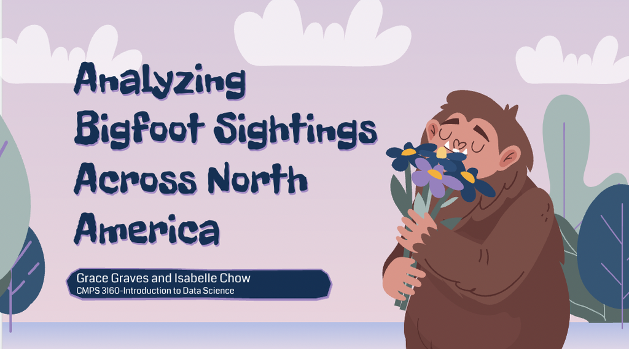

# Bigfoot Sightings Across North America

**Grace Graves and Isabelle Chow**

### Background and Plan

This team will be investigating data sets related to Bigfoot (Sasquatch, Yeti, Yowie, Skunk ape, etc) a bipedal ape-like creature said to inhabit the forests of North America and potentially similar environments around the world. Tales of creatures similar to Bigfoot have been woven into the mythologies of indigineous people and detailed reports and investigations of its existence have occurred since the early 1700s. More information about the history of Bigfoot can be found [here](https://www.oregonencyclopedia.org/articles/bigfoot_sasquatch_legend/#.Y0nrG-zMI6E). Although the majority of mainstream scientests have historically declared the existence of Bigfoot a hoax, many sightings still occur to this day, and the existence of Bigfoot is a widely publicized and debated topic in pop culture and cryptozoology. In this project, the team wanted to examine this phenomenon by exploring data related to the location, time of year and day, classification, and context of the sighting as well as weather data considering temperature.

In this project, the team will consider the following questions:

- What is the distribution of Bigfoot sightings across North America? Where are the sightings concentrated?
- Was there a time (year or time of year) when Bigfoot was more active and what factors affected that time?
- What were the weather conditions of the incidences and is there a correlation between certain weather conditions and a higher amount of sightings?
- Do descriptions of the sightings indicate any patterns in how or where more bigfoots are found?

In this project, the team would like to analyze the sightings dataset by examining trends in the time and kind of sighting. We will also find dates of release of certain Bigfoot related media and see if this has a relationship with the sighting frequency as well. We will use a temperature dataset to see if there is a relationship between weather and sightings. This will continue to help us answer our questions on location and distribution of Sasquatch across North America, giving us an overall more holistic and detailed understanding of this mysterious creature, and look for patterns that might point us to optimal bigfoot sighting settings.

```python
from google.colab import drive
drive.mount('/content/drive')
%cd /content/drive/MyDrive/BigfootDataScienceProject/
```

```
/content/drive/.shortcut-targets-by-id/1WVWh0s9coKx-LzaErUE6N7YbcIg9B1aI/BigfootDataScienceProject
```

```python
# Import all the libraries we will be using in the project

import pandas as pd
import numpy as np

! pip install geopandas
import geopandas as gpd
from shapely.geometry import Point
from geopandas import GeoDataFrame
! pip install geoplot
import geoplot as gplt

import plotly.express as px
import matplotlib.pyplot as plt
! pip install seaborn
import seaborn as sns
```

## Main Dataset: Bigfoot Sightings

This table is from the primary authority on Bigfoot sitings, the Bigfoot Field Researchers Organization, or BFRO. It is a "comprehensive database of credible sightings and related reports, maintained by an all volunteer network of bigfoot/sasquatch researchers, archivists, and investigators in the United States and Canada founded in 1995."(https://www.bfro.net/gdb). This dataset contains thousands of reports of Bigfoot sightings, including a short description of the circumstance of the sighting, a classification (*A: Clear sighting, misinterpretation or misidentification can be ruled out with great confidence B: Possible sasquatch observed at a great distance or in poor lighting C: Second and third-hand reports*), as well as a date and a time, latitude, and longitutde. This team chose this data set as it offers a fantastic base of every officially documented Bigfoot sighting as well as good base information that could help us easily answer questions and draw connections to other potential datasets we will load and organize in the future. Because Sasquatches are not scientifically confirmed to be a real species of animal, verification and reliability of data sources related to them are always going to be difficult, but this was the best option available to the team given the very large sample size and objective intentions of the BFRO as a continuously growing database in existence for over 20 years.

```python
!pwd
```

```
/content/drive/.shortcut-targets-by-id/1WVWh0s9coKx-LzaErUE6N7YbcIg9B1aI/BigfootDataScienceProject
```

```python
# Unzip dataset
#!mkdir -p ./data/archive
#!unzip ./data/archive.zip -d ./data/sightings
```

```python
bf = pd.read_csv("./data/sightings/bfro-report-locations.csv")
bf
```

|  | number | title | classification | timestamp | latitude | longitude |
| --- | --- | --- | --- | --- | --- | --- |
| 0 | 637 | Report 637: Campers' encounter just after dark... | Class A | 2000-06-16T12:00:00Z | 61.50000 | -142.90000 |
| 1 | 2917 | Report 2917: Family observes large biped from car | Class A | 1995-05-15T12:00:00Z | 55.18720 | -132.79820 |
| 2 | 7963 | Report 7963: Sasquatch walks past window of ho... | Class A | 2004-02-09T12:00:00Z | 55.20350 | -132.82020 |
| 3 | 9317 | Report 9317: Driver on Alcan Highway has noon,... | Class A | 2004-06-18T12:00:00Z | 62.93750 | -141.56670 |
| 4 | 13038 | Report 13038: Snowmobiler has encounter in dee... | Class A | 2004-02-15T12:00:00Z | 61.05950 | -149.78530 |
| ... | ... | ... | ... | ... | ... | ... |
| 3805 | 4159 | Report 4159: Campers hear unusual grunting sou... | Class C | 1995-11-15T12:00:00Z | 31.22333 | -94.96611 |
| 3806 | 175 | Report 175: Campers encounter large animal nea... | Class C | 2000-07-30T12:00:00Z | 47.47745 | -121.04150 |
| 3807 | 945 | Report 945: Creature with red glowing eyes seen | Class C | 1999-03-19T12:00:00Z | 47.57778 | -124.29330 |
| 3808 | 1387 | Report 1387: Father and son hear heavy footste... | Class C | 1983-08-17T12:00:00Z | 47.51030 | -122.04560 |
| 3809 | 3044 | Report 3044: Second-hand report of creature lo... | Class C | 1975-09-10T12:00:00Z | 43.98694 | -91.33662 |

3810 rows × 6 columns

### Difficulties with Data

Although the dataset contains some very useful information about sasquatch sightings, there could be problems in using the data in it's current format. For starters, the "timestamp" column contains very important information on the year, month, day, and time of the sightings but isn't going to be easy to use in it's current format: a string of values all in one column. According to the principles of tidy data, each column should represent a value in the observation. As it stands, the "timestamp" column contains multiple values, even though they are of the same category. The current format is also difficult to summarize using pandas summary functions. The set also duplicates some data. The columns "number" and "title" both have a report number in them. The "classification" column with values "Class A", "Class B", and "Class C" is a bit redundant. This team will resolve all of these issues in the code below.

```python
bf[["report #", "description", "extra"]] = bf["title"].str.split(": ", expand=True) #split the title into report number and description of sighting
bf[["date", "time"]] = bf["timestamp"].str.split("T", expand=True) #split the timestamp into date and time columns
bf[["year", "month", "day"]] = bf["date"].str.split("-", expand=True) #split the date into year, month, and day
bf
```

|  | number | title | classification | timestamp | latitude | longitude | report # | description | extra | date | time | year | month | day |
| --- | --- | --- | --- | --- | --- | --- | --- | --- | --- | --- | --- | --- | --- | --- |
| 0 | 637 | Report 637: Campers' encounter just after dark... | Class A | 2000-06-16T12:00:00Z | 61.50000 | -142.90000 | Report 637 | Campers' encounter just after dark in the Wran... | None | 2000-06-16 | 12:00:00Z | 2000 | 06 | 16 |
| 1 | 2917 | Report 2917: Family observes large biped from car | Class A | 1995-05-15T12:00:00Z | 55.18720 | -132.79820 | Report 2917 | Family observes large biped from car | None | 1995-05-15 | 12:00:00Z | 1995 | 05 | 15 |
| 2 | 7963 | Report 7963: Sasquatch walks past window of ho... | Class A | 2004-02-09T12:00:00Z | 55.20350 | -132.82020 | Report 7963 | Sasquatch walks past window of house at night | None | 2004-02-09 | 12:00:00Z | 2004 | 02 | 09 |
| 3 | 9317 | Report 9317: Driver on Alcan Highway has noon,... | Class A | 2004-06-18T12:00:00Z | 62.93750 | -141.56670 | Report 9317 | Driver on Alcan Highway has noon, road encount... | None | 2004-06-18 | 12:00:00Z | 2004 | 06 | 18 |
| 4 | 13038 | Report 13038: Snowmobiler has encounter in dee... | Class A | 2004-02-15T12:00:00Z | 61.05950 | -149.78530 | Report 13038 | Snowmobiler has encounter in deep snow near Po... | None | 2004-02-15 | 12:00:00Z | 2004 | 02 | 15 |
| ... | ... | ... | ... | ... | ... | ... | ... | ... | ... | ... | ... | ... | ... | ... |
| 3805 | 4159 | Report 4159: Campers hear unusual grunting sou... | Class C | 1995-11-15T12:00:00Z | 31.22333 | -94.96611 | Report 4159 | Campers hear unusual grunting sound from behin... | None | 1995-11-15 | 12:00:00Z | 1995 | 11 | 15 |
| 3806 | 175 | Report 175: Campers encounter large animal nea... | Class C | 2000-07-30T12:00:00Z | 47.47745 | -121.04150 | Report 175 | Campers encounter large animal near Cle Elum | None | 2000-07-30 | 12:00:00Z | 2000 | 07 | 30 |
| 3807 | 945 | Report 945: Creature with red glowing eyes seen | Class C | 1999-03-19T12:00:00Z | 47.57778 | -124.29330 | Report 945 | Creature with red glowing eyes seen | None | 1999-03-19 | 12:00:00Z | 1999 | 03 | 19 |
| 3808 | 1387 | Report 1387: Father and son hear heavy footste... | Class C | 1983-08-17T12:00:00Z | 47.51030 | -122.04560 | Report 1387 | Father and son hear heavy footsteps made by an... | None | 1983-08-17 | 12:00:00Z | 1983 | 08 | 17 |
| 3809 | 3044 | Report 3044: Second-hand report of creature lo... | Class C | 1975-09-10T12:00:00Z | 43.98694 | -91.33662 | Report 3044 | Second-hand report of creature looking in at w... | None | 1975-09-10 | 12:00:00Z | 1975 | 09 | 10 |

3810 rows × 14 columns

```python
# Map classes to letters for readability and ease of use

bf["class"] = bf["classification"].map({
    "Class A": "A",
    "Class B": "B",
    "Class C": "C"
})
```

```python
# Delete duplicate or unnecessary rows

del bf["report #"] #duplicate
del bf["extra"] #unnecessary
del bf["timestamp"] #duplicate
del bf["title"] #duplicate
del bf["time"] #unnecessary (all values are exactly the same and therefore not accurate)
del bf["date"] #duplicate
bf
```

|  | number | classification | latitude | longitude | description | year | month | day | class |
| --- | --- | --- | --- | --- | --- | --- | --- | --- | --- |
| 0 | 637 | Class A | 61.50000 | -142.90000 | Campers' encounter just after dark in the Wran... | 2000 | 06 | 16 | A |
| 1 | 2917 | Class A | 55.18720 | -132.79820 | Family observes large biped from car | 1995 | 05 | 15 | A |
| 2 | 7963 | Class A | 55.20350 | -132.82020 | Sasquatch walks past window of house at night | 2004 | 02 | 09 | A |
| 3 | 9317 | Class A | 62.93750 | -141.56670 | Driver on Alcan Highway has noon, road encount... | 2004 | 06 | 18 | A |
| 4 | 13038 | Class A | 61.05950 | -149.78530 | Snowmobiler has encounter in deep snow near Po... | 2004 | 02 | 15 | A |
| ... | ... | ... | ... | ... | ... | ... | ... | ... | ... |
| 3805 | 4159 | Class C | 31.22333 | -94.96611 | Campers hear unusual grunting sound from behin... | 1995 | 11 | 15 | C |
| 3806 | 175 | Class C | 47.47745 | -121.04150 | Campers encounter large animal near Cle Elum | 2000 | 07 | 30 | C |
| 3807 | 945 | Class C | 47.57778 | -124.29330 | Creature with red glowing eyes seen | 1999 | 03 | 19 | C |
| 3808 | 1387 | Class C | 47.51030 | -122.04560 | Father and son hear heavy footsteps made by an... | 1983 | 08 | 17 | C |
| 3809 | 3044 | Class C | 43.98694 | -91.33662 | Second-hand report of creature looking in at w... | 1975 | 09 | 10 | C |

3810 rows × 9 columns

Columns were split to allow each variable of a report to be used to the fullest in the summary and interpretation.

```python
# Reorder/rename columns

bf = bf[['number', 'description', 'class', 'longitude', 'latitude', 'year', 'month', 'day']]
bf.rename(columns= {"number":"report_number"}, inplace=True)
bf
```

|  | report_number | description | class | longitude | latitude | year | month | day |
| --- | --- | --- | --- | --- | --- | --- | --- | --- |
| 0 | 637 | Campers' encounter just after dark in the Wran... | A | -142.90000 | 61.50000 | 2000 | 06 | 16 |
| 1 | 2917 | Family observes large biped from car | A | -132.79820 | 55.18720 | 1995 | 05 | 15 |
| 2 | 7963 | Sasquatch walks past window of house at night | A | -132.82020 | 55.20350 | 2004 | 02 | 09 |
| 3 | 9317 | Driver on Alcan Highway has noon, road encount... | A | -141.56670 | 62.93750 | 2004 | 06 | 18 |
| 4 | 13038 | Snowmobiler has encounter in deep snow near Po... | A | -149.78530 | 61.05950 | 2004 | 02 | 15 |
| ... | ... | ... | ... | ... | ... | ... | ... | ... |
| 3805 | 4159 | Campers hear unusual grunting sound from behin... | C | -94.96611 | 31.22333 | 1995 | 11 | 15 |
| 3806 | 175 | Campers encounter large animal near Cle Elum | C | -121.04150 | 47.47745 | 2000 | 07 | 30 |
| 3807 | 945 | Creature with red glowing eyes seen | C | -124.29330 | 47.57778 | 1999 | 03 | 19 |
| 3808 | 1387 | Father and son hear heavy footsteps made by an... | C | -122.04560 | 47.51030 | 1983 | 08 | 17 |
| 3809 | 3044 | Second-hand report of creature looking in at w... | C | -91.33662 | 43.98694 | 1975 | 09 | 10 |

3810 rows × 8 columns

```python
bf.dtypes
```

```
report_number      int64
description       object
class             object
longitude        float64
latitude         float64
year              object
month             object
day               object
dtype: object
```

```python
# Fix dtypes to accurately reflect types of data

bf["report_number"] = bf["report_number"].astype(str)
bf[["year", "month", "day"]] = bf[["year", "month", "day"]].astype(int)
bf
```

|  | report_number | description | class | longitude | latitude | year | month | day |
| --- | --- | --- | --- | --- | --- | --- | --- | --- |
| 0 | 637 | Campers' encounter just after dark in the Wran... | A | -142.90000 | 61.50000 | 2000 | 6 | 16 |
| 1 | 2917 | Family observes large biped from car | A | -132.79820 | 55.18720 | 1995 | 5 | 15 |
| 2 | 7963 | Sasquatch walks past window of house at night | A | -132.82020 | 55.20350 | 2004 | 2 | 9 |
| 3 | 9317 | Driver on Alcan Highway has noon, road encount... | A | -141.56670 | 62.93750 | 2004 | 6 | 18 |
| 4 | 13038 | Snowmobiler has encounter in deep snow near Po... | A | -149.78530 | 61.05950 | 2004 | 2 | 15 |
| ... | ... | ... | ... | ... | ... | ... | ... | ... |
| 3805 | 4159 | Campers hear unusual grunting sound from behin... | C | -94.96611 | 31.22333 | 1995 | 11 | 15 |
| 3806 | 175 | Campers encounter large animal near Cle Elum | C | -121.04150 | 47.47745 | 2000 | 7 | 30 |
| 3807 | 945 | Creature with red glowing eyes seen | C | -124.29330 | 47.57778 | 1999 | 3 | 19 |
| 3808 | 1387 | Father and son hear heavy footsteps made by an... | C | -122.04560 | 47.51030 | 1983 | 8 | 17 |
| 3809 | 3044 | Second-hand report of creature looking in at w... | C | -91.33662 | 43.98694 | 1975 | 9 | 10 |

3810 rows × 8 columns

```python
# Drop longitude and latitude values outside range of possibility

bf.drop(bf[(bf['longitude'] >180) | (bf['longitude'] < -180) | (bf['latitude'] < -90) | (bf['latitude'] > 90)].index, inplace=True)
bf
```

|  | report_number | description | class | longitude | latitude | year | month | day |
| --- | --- | --- | --- | --- | --- | --- | --- | --- |
| 0 | 637 | Campers' encounter just after dark in the Wran... | A | -142.90000 | 61.50000 | 2000 | 6 | 16 |
| 1 | 2917 | Family observes large biped from car | A | -132.79820 | 55.18720 | 1995 | 5 | 15 |
| 2 | 7963 | Sasquatch walks past window of house at night | A | -132.82020 | 55.20350 | 2004 | 2 | 9 |
| 3 | 9317 | Driver on Alcan Highway has noon, road encount... | A | -141.56670 | 62.93750 | 2004 | 6 | 18 |
| 4 | 13038 | Snowmobiler has encounter in deep snow near Po... | A | -149.78530 | 61.05950 | 2004 | 2 | 15 |
| ... | ... | ... | ... | ... | ... | ... | ... | ... |
| 3805 | 4159 | Campers hear unusual grunting sound from behin... | C | -94.96611 | 31.22333 | 1995 | 11 | 15 |
| 3806 | 175 | Campers encounter large animal near Cle Elum | C | -121.04150 | 47.47745 | 2000 | 7 | 30 |
| 3807 | 945 | Creature with red glowing eyes seen | C | -124.29330 | 47.57778 | 1999 | 3 | 19 |
| 3808 | 1387 | Father and son hear heavy footsteps made by an... | C | -122.04560 | 47.51030 | 1983 | 8 | 17 |
| 3809 | 3044 | Second-hand report of creature looking in at w... | C | -91.33662 | 43.98694 | 1975 | 9 | 10 |

3801 rows × 8 columns

```python
bf.describe()
```

|  | longitude | latitude | year | month | day |
| --- | --- | --- | --- | --- | --- |
| count | 3801.000000 | 3801.000000 | 3801.000000 | 3801.000000 | 3801.000000 |
| mean | -97.999788 | 39.757491 | 1997.426467 | 7.207577 | 14.202315 |
| std | 16.965645 | 6.070532 | 14.078200 | 3.090785 | 8.619828 |
| min | -167.131000 | 25.141000 | 1869.000000 | 1.000000 | 1.000000 |
| 25% | -118.375000 | 35.474500 | 1988.000000 | 5.000000 | 7.000000 |
| 50% | -92.304600 | 39.492650 | 2002.000000 | 8.000000 | 15.000000 |
| 75% | -83.282650 | 44.705960 | 2007.000000 | 10.000000 | 20.000000 |
| max | -63.836830 | 69.500000 | 2053.000000 | 12.000000 | 31.000000 |

## Secondary Dataset: Average Temperatures

To simplify the weather data, we will scrape a list of average temperatures by US state. This will give us insight into the potential habitation preferences of Bigfoot and allow us to predict the best state to go to to spot bigfoot or what places abroad could be home to other sasquatches.

```python
import requests

# scrape website to get html

headers = {'User-Agent': 'Mozilla/5.0 (Macintosh; Intel Mac OS X 10_10_1) AppleWebKit/537.36 (KHTML, like Gecko) Chrome/39.0.2171.95 Safari/537.36'}

r = requests.get('https://www.currentresults.com/Weather/US/average-annual-state-temperatures.php', headers=headers, timeout=10)
print(r.status_code)
```

```
200
```

```python
from bs4 import BeautifulSoup

# beautify the html for readability and extract table

soup = BeautifulSoup(r.content)
print(soup.find("table").prettify()[:600])
```

```
<table class="articletable tablecol-1-left">
 <caption>
  Average annual temperature for each state.
 </caption>
 <thead>
  <tr>
   <th class="left">
    State
   </th>
   <th>
    Avg °F
   </th>
   <th>
    Avg °C
   </th>
   <th>
    Rank
   </th>
  </tr>
 </thead>
 <tbody>
  <tr>
   <td>
    <a href="/Weather/Alabama/average-annual-temperatures.php">
     Alabama
    </a>
   </td>
   <td>
    62.8
   </td>
   <td>
    17.1
   </td>
   <td>
    7
   </td>
  </tr>
  <tr>
   <td>
    <a href="/Weather/Alaska/average-annual-temperatures.php">
     Alaska
    </a>
   </td>
   <td>
    26.6
   <
```

```python
# Since the data we want is split we will make
# every piece of the table we want into a dataframe then concatenate them

avg_weather_tables = []
for t in soup.findAll("table"):
    df_t = pd.read_html(str(t))
    avg_weather_tables.append(df_t[0])

avg_weather = pd.concat(avg_weather_tables)
avg_weather.reset_index(inplace=True)
display(avg_weather.head(10))
```

|  | index | State | Avg °F | Avg °C | Rank |
| --- | --- | --- | --- | --- | --- |
| 0 | 0 | Alabama | 62.8 | 17.1 | 7 |
| 1 | 1 | Alaska | 26.6 | -3.0 | 50 |
| 2 | 2 | Arizona | 60.3 | 15.7 | 10 |
| 3 | 3 | Arkansas | 60.4 | 15.8 | 9 |
| 4 | 4 | California | 59.4 | 15.2 | 12 |
| 5 | 5 | Colorado | 45.1 | 7.3 | 39 |
| 6 | 6 | Connecticut | 49.0 | 9.4 | 29 |
| 7 | 7 | Delaware | 55.3 | 12.9 | 16 |
| 8 | 8 | Florida | 70.7 | 21.5 | 1 |
| 9 | 9 | Georgia | 63.5 | 17.5 | 5 |

```python
avg_weather.drop(["index", "Avg °C"], axis=1, inplace=True)
avg_weather.head(10)
```

|  | State | Avg °F | Rank |
| --- | --- | --- | --- |
| 0 | Alabama | 62.8 | 7 |
| 1 | Alaska | 26.6 | 50 |
| 2 | Arizona | 60.3 | 10 |
| 3 | Arkansas | 60.4 | 9 |
| 4 | California | 59.4 | 12 |
| 5 | Colorado | 45.1 | 39 |
| 6 | Connecticut | 49.0 | 29 |
| 7 | Delaware | 55.3 | 16 |
| 8 | Florida | 70.7 | 1 |
| 9 | Georgia | 63.5 | 5 |

```python
# giving each state a code for mapping purposes

avg_weather["state_code"] = ["AL", "AK", "AZ", "AR", "CA", "CO", "CT", "DE",
                             "FL", "GA", "HI", "ID", "IL", "IN", "IA", "KS",
                             "KY", "LA", "ME", "MD", "MA", "MI", "MN", "MS",
                             "MO", "MT", "NE", "NV", "NH", "NJ", "NM", "NY",
                             "NC", "ND", "OH", "OK", "OR", "PA", "RI", "SC",
                             "SD", "TN", "TX", "UT", "VT", "VA", "WA", "WV",
                             "WI", "WY"]
```

```python
avg_weather
```

|  | State | Avg °F | Rank | state_code |
| --- | --- | --- | --- | --- |
| 0 | Alabama | 62.8 | 7 | AL |
| 1 | Alaska | 26.6 | 50 | AK |
| 2 | Arizona | 60.3 | 10 | AZ |
| 3 | Arkansas | 60.4 | 9 | AR |
| 4 | California | 59.4 | 12 | CA |
| 5 | Colorado | 45.1 | 39 | CO |
| 6 | Connecticut | 49.0 | 29 | CT |
| 7 | Delaware | 55.3 | 16 | DE |
| 8 | Florida | 70.7 | 1 | FL |
| 9 | Georgia | 63.5 | 5 | GA |
| 10 | Hawaii | 70.0 | 2 | HI |
| 11 | Idaho | 44.4 | 40 | ID |
| 12 | Illinois | 51.8 | 23 | IL |
| 13 | Indiana | 51.7 | 25 | IN |
| 14 | Iowa | 47.8 | 36 | IA |
| 15 | Kansas | 54.3 | 19 | KS |
| 16 | Kentucky | 55.6 | 15 | KY |
| 17 | Louisiana | 66.4 | 3 | LA |
| 18 | Maine | 41.0 | 48 | ME |
| 19 | Maryland | 54.2 | 20 | MD |
| 20 | Massachusetts | 47.9 | 35 | MA |
| 21 | Michigan | 44.4 | 40 | MI |
| 22 | Minnesota | 41.2 | 47 | MN |
| 23 | Mississippi | 63.4 | 6 | MS |
| 24 | Missouri | 54.5 | 18 | MO |
| 25 | Montana | 42.7 | 45 | MT |
| 26 | Nebraska | 48.8 | 30 | NE |
| 27 | Nevada | 49.9 | 28 | NV |
| 28 | New Hampshire | 43.8 | 42 | NH |
| 29 | New Jersey | 52.7 | 22 | NJ |
| 30 | New Mexico | 53.4 | 21 | NM |
| 31 | New York | 45.4 | 37 | NY |
| 32 | North Carolina | 59.0 | 13 | NC |
| 33 | North Dakota | 40.4 | 49 | ND |
| 34 | Ohio | 50.7 | 26 | OH |
| 35 | Oklahoma | 59.6 | 11 | OK |
| 36 | Oregon | 48.4 | 33 | OR |
| 37 | Pennsylvania | 48.8 | 30 | PA |
| 38 | Rhode Island | 50.1 | 27 | RI |
| 39 | South Carolina | 62.4 | 8 | SC |
| 40 | South Dakota | 45.2 | 38 | SD |
| 41 | Tennessee | 57.6 | 14 | TN |
| 42 | Texas | 64.8 | 4 | TX |
| 43 | Utah | 48.6 | 32 | UT |
| 44 | Vermont | 42.9 | 44 | VT |
| 45 | Virginia | 55.1 | 17 | VA |
| 46 | Washington | 48.3 | 34 | WA |
| 47 | West Virginia | 51.8 | 23 | WV |
| 48 | Wisconsin | 43.1 | 43 | WI |
| 49 | Wyoming | 42.0 | 46 | WY |

```python
avg_weather.dtypes
```

```
State          object
Avg °F        float64
Rank            int64
state_code     object
dtype: object
```

## Exploratory Data Analysis

Knowing the year where Bigfoot sightings is interesting as we could potentially link it to historical trends like the rise of information sharing on the internet or certain news trends/cycles that might influence how interested the general public is in Bigfoot. We also know early instances of recorded Bigfoot sightings (1869!) which is interesting to think about people hundreds of years ago recording seeing these creatures as well.

Knowing the time of year when most Bigfoot sightings occur is useful as in the future we could link this information to yearly camping/hunting statistics and see if there is any correlation between more people being out in the forest for a certain reason (hunting, camping, etc) and a greater frequency of seeing Bigfoot, or if Bigfoots are more attracted to urban infrastructures like national park facilities and roadways. According to our EDA, Bigfoots are more likely to be seein in the late summer and fall months with October, July, and August being in the top three months for sightings.

Further data analysis has now been done concerning location of sightings and temperature data for the US. The maps and charts below will assist this team in determining areas of focus for the questions we want to answer and models we plan to build. For example, the map of sightings has already clued this team into the possibility of a relationship between sasquatch sightings and elevation changes (the presence of mountains).

```python
# What class of reports are most common?
bf["class"].value_counts()
```

```
A    1892
B    1890
C      19
Name: class, dtype: int64
```

Class A and B reports are most common.

Most reported sightings happened between 2003-2007. If we want to see this in a visual we can plot the values.

**Frequency of Sightings by Year**

```python
# What year were sightings the most common in?
bf["year"].value_counts()
```

```
2004    250
2005    226
2006    188
2007    170
2003    154
       ...
1921      1
1869      1
1937      1
1947      1
1930      1
Name: year, Length: 81, dtype: int64
```

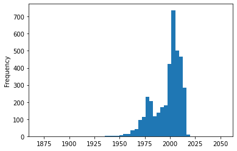

```python
bf.year.plot.hist(bins=50)
```

This graph is interesting when compared to a few major events in Bigfoot culture history in the US: [The Patterson Film](https://en.wikipedia.org/wiki/Patterson%E2%80%93Gimlin_film)(1967), releases of Bigfoot media in the 80s like the [Harry and the Hendersons movie](https://www.imdb.com/title/tt0093148/) and similar films, and the release of the popular Animal Planet Show [Finding Bigfoot](https://www.imdb.com/title/tt1948830/)(2011). The Patterson film is one of the most famous images and forms of evidence pointing to Bigfoot's existence in modern North American Bigfoot lore. Despite the release of this film and various other forms of media, there seems to be little correlation between the times of releases and the larger spikes in sightings over the years. This observation would suggest that the patters of sightings are more reliable as they are independent from any periods of media frenzy surrounding Bigfoot.

**Month vs Sighting Frequency**

```python
# Which time of year is bigfoot most active?
bf["month"].value_counts()
```

```
10    496
7     481
8     458
9     401
11    364
6     344
5     257
1     246
4     214
12    209
3     171
2     160
Name: month, dtype: int64
```

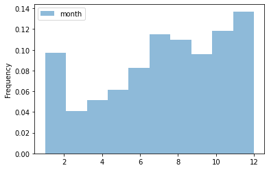

```python
bf
bf.month.plot.hist(alpha=.5, density=True, legend=True)
```

```python
bf
```

|  | report_number | description | class | longitude | latitude | year | month | day |
| --- | --- | --- | --- | --- | --- | --- | --- | --- |
| 0 | 637 | Campers' encounter just after dark in the Wran... | A | -142.90000 | 61.50000 | 2000 | 6 | 16 |
| 1 | 2917 | Family observes large biped from car | A | -132.79820 | 55.18720 | 1995 | 5 | 15 |
| 2 | 7963 | Sasquatch walks past window of house at night | A | -132.82020 | 55.20350 | 2004 | 2 | 9 |
| 3 | 9317 | Driver on Alcan Highway has noon, road encount... | A | -141.56670 | 62.93750 | 2004 | 6 | 18 |
| 4 | 13038 | Snowmobiler has encounter in deep snow near Po... | A | -149.78530 | 61.05950 | 2004 | 2 | 15 |
| ... | ... | ... | ... | ... | ... | ... | ... | ... |
| 3805 | 4159 | Campers hear unusual grunting sound from behin... | C | -94.96611 | 31.22333 | 1995 | 11 | 15 |
| 3806 | 175 | Campers encounter large animal near Cle Elum | C | -121.04150 | 47.47745 | 2000 | 7 | 30 |
| 3807 | 945 | Creature with red glowing eyes seen | C | -124.29330 | 47.57778 | 1999 | 3 | 19 |
| 3808 | 1387 | Father and son hear heavy footsteps made by an... | C | -122.04560 | 47.51030 | 1983 | 8 | 17 |
| 3809 | 3044 | Second-hand report of creature looking in at w... | C | -91.33662 | 43.98694 | 1975 | 9 | 10 |

3801 rows × 8 columns

## Description Word Tokenization

An untapped resource we find in the dataset is the description. To gain insight into this data without reading every line, we tokenized the descriptions given by the observers. We can use this to analyze which words, whether they be objects, people or places had the most occurences throughout the data. This will help us further determine what circumstances bigfoots show up in frequently.

```python
import nltk #Special thanks to Karthik for suggesting tokenizing the description and analyzing word instances
import re
from collections import Counter #used Counter collection to count instances of each word

description = bf['description'].copy() #takes description just from the bf dataset
description.columns = ['DESCRIPTION']
desc = description.str.cat(sep= ' ') #concatenate all descriptions into one large string
```

```python
desc
splitdesc = desc.split(' ') #split my large text list into individual words
splitdesc
WordCounts = Counter(splitdesc) #use counter to count instances of each word
print(WordCounts.most_common())
```

```
[('near', 1683), ('a', 1215), ('sighting', 1015), ('of', 902), ('in', 888), ('by', 749), ('the', 690), ('and', 608), ('on', 570), ('at', 495), ('Possible', 466), ('encounter', 375), ('has', 368), ('possible', 357), ('while', 323), ('vocalizations', 296), ('Lake', 290), ('outside', 286), ('night', 26…
```

**Description Analysis**

Aside from conjunction words and words that don't really tell us any details about the sighting ("near", "sighting", "Possible", "encounter") the most common words in the descriptions are "vocalizations" "Lake" "night" and "outside", suggesting that many of these sightings vocalizations were heard. If you wanted to see a bigfoot, maybe standing by a lake at night outside would be more probable to encounter one as there are more descritions with these words. Another interesting observation is that the word "Man" has 230 counts whereas "Woman" only has 111, suggesting that more men see Bigfoot than women by a significant margin.

```python
desc.count('Campers') + desc.count('campers') + desc.count('campsite') + desc.count('tent') #use the .count function to count instances of relevant or interesting words
```

```
165
```

```python
desc.count('Forest') + desc.count('forest') + desc.count('woods') + desc.count('Woods') + desc.count('tree')
```

```
305
```

Lots of mentions of woods and camping, as expected. Bigfoot is most clasically seen in the woods.

```python
desc.count('highway') + desc.count('Highway') + desc.count('Freeway') + desc.count('freeway')
```

```
52
```

```python
desc.count('Desert') + desc.count('desert') + desc.count('hot') + desc.count('arid')
```

```
57
```

Less mentions of bigfoot near highways or freeways and in deserts or hot and arid places.

```python
desc.count('Sasquatch') + desc.count('sasquatch') + desc.count('Squatch')
```

```
87
```

```python
desc.count('Bigfoot') + desc.count('bigfoot')
```

```
113
```

```python
desc.count('Yowie') + desc.count('Yeti')+ desc.count('Skunk-Ape')
```

```
1
```

Bigfoot is most commonly referred to as Bigfoot or Squatch/Sasquatch. Other names for bigfoot are less used in this dataset.

**Sightings vs Latitude over Year and Month Scatter Plot**

Location of the sightings is of the utmost importance as we focus in on one of our main questions: does the weather/temperature affect the probability of seeing Bigfoot. Below we will plot the longitude and latitude of each sighting on a map to visualize the distribution of sightings in North America. Note that this includes sightings overtime. Future plots contrasting sighting location over time could prove useful in determining potential migration habits or simply the spreading of the Bigfoot rumor.

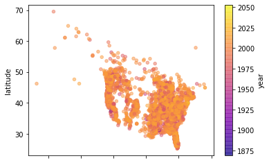

```python
bf.plot.scatter(x="longitude", y="latitude", c="year", cmap="plasma", alpha=.5)
```

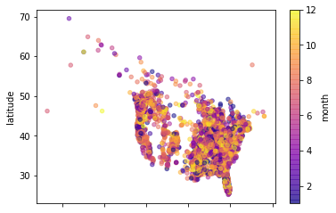

```python
bf.plot.scatter(x="longitude", y="latitude", c="month", cmap="plasma", alpha=.5)
```

We plotted the sightings across the scatter plot by latitude and longitude with the color variations being by month. Bigfoots show no annual migratory patterns across North America as there are no patterns in the sightings, month, and geographical location. This rules out any potential confusion we could have experience in considering all of the years data at once. Since there is no clear change in pattern across time, we can use all the data at once.

**Sightings over a Map of North America**

```
(20.141, 74.5)
```

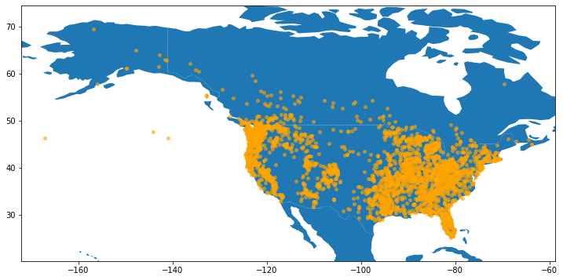

```python
# Techniques used to load and size this plot derived from https://geopandas.org/en/stable/docs/user_guide/mapping.html
# and https://gis.stackexchange.com/questions/375582/zoom-to-a-plot-with-geopandas-based-on-data-from-csv-and-shapefile

geometry = [Point(xy) for xy in zip(bf['longitude'], bf['latitude'])]
gdf = GeoDataFrame(bf, geometry=geometry)

#this is a simple map that goes with geopandas
world = gpd.read_file(gpd.datasets.get_path('naturalearth_lowres'))
ax = gdf.plot(ax=world.plot(figsize=(20, 6)), marker='o', color='orange', markersize=15, aspect='auto', alpha=.6);
minx, miny, maxx, maxy = gdf.total_bounds
ax.set_xlim(minx-5, maxx+5)
ax.set_ylim(miny-5, maxy+5)
```

**Heatmap of Temperature across the United States Divided by State**

```python
# Techniques used to load and size this plot derived from https://towardsdatascience.com/simplest-way-of-creating-a-choropleth-map-by-u-s-states-in-python-f359ada7735e
fig = px.choropleth(avg_weather,
                    locations='state_code',
                    locationmode="USA-states",
                    scope="usa",
                    color='Avg °F',
                    color_continuous_scale="plasma",
                    )
fig.show()
```

[interactive chart not shown]

Following the Location of the sightings, climate data across the region of interest can be visualized above. As you can see (and probably intuit), temperature varies mainly from North to South. The sighting map does not seem to portray the same pattern at first glance.

## Answering the Question

So does Bigfoot have a preference according to temperature. The graphs below attempt to answer this question.

The bar graphs show variance in sighting frequency across longitude and latitude. The first (longitude) shows two spikes potentially indicating a correlation between longitudinal factors and bigfoot. However, the latitude bar graph shows a much weaker correlation to sighting frequency, pushing away the idea that Bigfoot prefers certain temperatures.

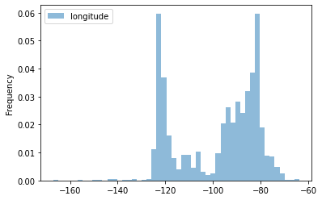

```python
bf.longitude.plot.hist(alpha=.5, density=True, legend=True, bins=50)
```

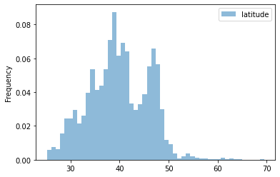

```python
bf.latitude.plot.hist(alpha=.5, density=True, legend=True, bins=50)
```

Now, we can create a heatmap to more concisely view the variation in frequency accross both longitude and latitude simultaneously.

```python
bf_freq_base = {
    "longitude" : ["25-30", "25-30", "25-30", "25-30", "30-35", "30-35", "30-35", "30-35", "35-40", "35-40", "35-40", "35-40", "40-45", "40-45", "40-45", "40-45", "45-50", "45-50", "45-50", "45-50"],
    "latitude" : ["60-80", "80-100", "100-120", "120-140", "60-80", "80-100", "100-120", "120-140", "60-80", "80-100", "100-120", "120-140", "60-80", "80-100", "100-120", "120-140", "60-80", "80-100", "100-120", "120-140"],
    "sightings" : [bf[(bf.latitude > 25) & (bf.latitude < 30) & (bf.longitude < -60) & (bf.longitude > -80)].report_number.count(),
                   bf[(bf.latitude > 25) & (bf.latitude < 30) & (bf.longitude < -80) & (bf.longitude > -100)].report_number.count(),
                   bf[(bf.latitude > 25) & (bf.latitude < 30) & (bf.longitude < -100) & (bf.longitude > -120)].report_number.count(),
                   bf[(bf.latitude > 25) & (bf.latitude < 30) & (bf.longitude < -120) & (bf.longitude > -140)].report_number.count(),
                   bf[(bf.latitude > 30) & (bf.latitude < 35) & (bf.longitude < -60) & (bf.longitude > -80)].report_number.count(),
                   bf[(bf.latitude > 30) & (bf.latitude < 35) & (bf.longitude < -80) & (bf.longitude > -100)].report_number.count(),
                   bf[(bf.latitude > 30) & (bf.latitude < 35) & (bf.longitude < -100) & (bf.longitude > -120)].report_number.count(),
                   bf[(bf.latitude > 30) & (bf.latitude < 35) & (bf.longitude < -120) & (bf.longitude > -140)].report_number.count(),
                   bf[(bf.latitude > 35) & (bf.latitude < 40) & (bf.longitude < -60) & (bf.longitude > -80)].report_number.count(),
                   bf[(bf.latitude > 35) & (bf.latitude < 40) & (bf.longitude < -80) & (bf.longitude > -100)].report_number.count(),
                   bf[(bf.latitude > 35) & (bf.latitude < 40) & (bf.longitude < -100) & (bf.longitude > -120)].report_number.count(),
                   bf[(bf.latitude > 35) & (bf.latitude < 40) & (bf.longitude < -120) & (bf.longitude > -140)].report_number.count(),
                   bf[(bf.latitude > 40) & (bf.latitude < 45) & (bf.longitude < -60) & (bf.longitude > -80)].report_number.count(),
                   bf[(bf.latitude > 40) & (bf.latitude < 45) & (bf.longitude < -80) & (bf.longitude > -100)].report_number.count(),
                   bf[(bf.latitude > 40) & (bf.latitude < 45) & (bf.longitude < -100) & (bf.longitude > -120)].report_number.count(),
                   bf[(bf.latitude > 40) & (bf.latitude < 45) & (bf.longitude < -120) & (bf.longitude > -140)].report_number.count(),
                   bf[(bf.latitude > 45) & (bf.latitude < 50) & (bf.longitude < -60) & (bf.longitude > -80)].report_number.count(),
                   bf[(bf.latitude > 45) & (bf.latitude < 50) & (bf.longitude < -80) & (bf.longitude > -100)].report_number.count(),
                   bf[(bf.latitude > 45) & (bf.latitude < 50) & (bf.longitude < -100) & (bf.longitude > -120)].report_number.count(),
                   bf[(bf.latitude > 45) & (bf.latitude < 50) & (bf.longitude < -120) & (bf.longitude > -140)].report_number.count(),]
}
```

```python
bf_freq = pd.DataFrame(bf_freq_base)
bf_freq
```

|  | longitude | latitude | sightings |
| --- | --- | --- | --- |
| 0 | 25-30 | 60-80 | 0 |
| 1 | 25-30 | 80-100 | 221 |
| 2 | 25-30 | 100-120 | 1 |
| 3 | 25-30 | 120-140 | 0 |
| 4 | 30-35 | 60-80 | 13 |
| 5 | 30-35 | 80-100 | 556 |
| 6 | 30-35 | 100-120 | 77 |
| 7 | 30-35 | 120-140 | 1 |
| 8 | 35-40 | 60-80 | 126 |
| 9 | 35-40 | 80-100 | 709 |
| 10 | 35-40 | 100-120 | 219 |
| 11 | 35-40 | 120-140 | 97 |
| 12 | 40-45 | 60-80 | 152 |
| 13 | 40-45 | 80-100 | 458 |
| 14 | 40-45 | 100-120 | 99 |
| 15 | 40-45 | 120-140 | 159 |
| 16 | 45-50 | 60-80 | 15 |
| 17 | 45-50 | 80-100 | 137 |
| 18 | 45-50 | 100-120 | 137 |
| 19 | 45-50 | 120-140 | 526 |

```python
bf_freq_pivot = bf_freq.pivot_table(
    index= ["latitude"], columns = ["longitude"],
    values = "sightings", aggfunc=np.max
)
bf_freq_pivot = bf_freq_pivot.reindex(["60-80", "80-100", "100-120", "120-140"], axis=0)
bf_freq_pivot
```

| longitude latitude | 25-30 | 30-35 | 35-40 | 40-45 | 45-50 |
| --- | --- | --- | --- | --- | --- |
| 60-80 | 0 | 13 | 126 | 152 | 15 |
| 80-100 | 221 | 556 | 709 | 458 | 137 |
| 100-120 | 1 | 77 | 219 | 99 | 137 |
| 120-140 | 0 | 1 | 97 | 159 | 526 |

[figure not shown]

```python
sns.heatmap(bf_freq_pivot)
```

## Conclusions

Upon starting this project, this team set out to learn more about the subject and patterns of the infamous yeti/sasquach/yowie known as Bigfoot, a wildly popular topic in cryptozoology. By extracting data from the world's largest and most reputable source of bigfoot sighting data, the Bigfoot Reasearchers Organization, we hoped to uncover correlations or lack thereof that might hint towards the creatures existence or the possibility of a hoax. Chief among our many many questions was the relationship between Bigfoot and his environment: do certain weather or climate factors determine whether Bigfoot is present/is more likely to be spotted? Through our exploratory data analysis, we explored all apsects of the bigfoot sighting data and attempted to eliminated future sources of confusion by ruling out correlations between date and location. We also examined patterns found in the description of the sighting and tried to find common themes in the descriptions. Our original hypothesis was that there will be a correlation between sighting location and average temperature potentially indicating bigfoot climate preference. We had hoped that this might lead to a predictive model of where you are more likely to spot bigfoot based on weather. However, our findings did not support this as temperature generally varies along changes in latitude and bigfoot sightings show no such pattern. In fact, frequency varies far more across longitude. As an interesting sidenote and a place for potential continued analysis, our map of bigfoot sightings is eerily congruent with maps of population density such as one found [here](https://vividmaps.com/us-population-density/). This has a variety of explanations ranging from "Bigfoot does not show preference for climate as a similar animal would so he isn’t real, people fake sightings everywhere" to "species of bigfoot have adapted to various climates." As you can see, it is easy to explain away correlations in either direction, making Bigfoot data difficult to deal with in terms of concrete conclusions.

```python
#Convert to HTML

%%shell
jupyter nbconvert --to html /content/drive/MyDrive/BigfootDataScienceProject/BigfootNotebook.ipynb
```

```
[NbConvertApp] Converting notebook /content/drive/MyDrive/BigfootDataScienceProject/BigfootNotebook.ipynb to html
[NbConvertApp] Writing 1314545 bytes to /content/drive/MyDrive/BigfootDataScienceProject/BigfootNotebook.html
```